# **DATA MINING - Projet Botanic**

- **Etudiants** : Faiçal SBAI & Alain BONDZA
- **Année de réalisation** : 2023
- **Sujet** :
- **Attrition des clients** : Identifier les clients qui sont attritionnistes en 2017 versus ceux qui sont non attritionnistes
- **Histoire et Contexte** :
- Botanic® est une chaîne de magasins fondée en France en 1995. L'enseigne propose une sélection de plantes, d'outils de jardinage, de produits bio pour le jardin et la maison, ainsi que des conseils de jardinage écologique. Elle se positionne sur la thématique du respect de l'environnement et la promotion du développement durable.
- Au travers d’un réseau de 70 magasins en France, Botanic® est le troisième groupe sur le marché de la jardinerie en France après InVivo et Truffaut.
- Comme toute entreprise, Botanic peut être confrontée à un défis de fidélisation de sa clientèle. L'attrition de ses clients peut être due à plusieurs facteurs, tels que :
  - Une Concurrence accrue à travers l'émergence de nouvelles enseignes, ou de la présence d'autres concurrents dans le secteur du jardinage et des produits bio.
  - Une évolution des préférences de ses consommateurs avec le temps, ce qui doit conduire Botanic® à s'adapter pour répondre aux nouvelles demandes du marché. Si les clients trouvent des alternatives plus attractives, ou si les produits de Botanic® ne correspondent plus à leurs besoins, cela peut entraîner une attrition des clients.
  - Un service à la clientèle médiocre, qui occasionne des problèmes récurrents, et peut entraîner une baisse de la fidélité des clients.
  - Les changements économiques dû aux fluctuations économiques, telles que les récessions ou les périodes de ralentissement économique, peuvent affecter les dépenses des consommateurs et entraîner une réduction de sa clientèle.
- **Botanic® en bref (2016-2017)** :
- **ACTIVITÉ** : jardinerie, animalerie, décoration, marché bio, bien-être.
- **CRÉATION** : 1977 (Les Serres du Salève) et 1995 (marque Botanic)
- **IMPLANTATION** : Archamps (siège social)
- **CHIFFRE D’AFFAIRES** : 364M€ (2016-2017)
- **EFFECTIFS** : 2200 salariés
- **MAGASINS (France)** : 70
- **RÉPARTITION DU CAPITAL** : les familles « opérationnelles » Blanchet et Bouchet viennent d’augmenter leur participation, les familles Verdonnet ayant vendu une grande partie de leurs parts. Les montants ne sont pas communiqués.
- **Demande de l'enseigne Botanic®** :

L’ambition de l'enseigne Botanic® est de devenir la jardinerie naturelle préférée des français en conciliant jardin et nature, croissance et responsabilité sociétale de l’entreprise. Pour cette raison, l'enseigne Botanic® souhaite : - Identifier les clients attritionnistes en 2017. - Disposer d'un modèle prédictif de l'attrition. - Obtenir des recommandations marketing de rétention des clients encore actifs mais à risque d'attrition en 2017.

- **Objectif** :
  - Expliquer (et mesurer) l'influence de facteurs sur un départ des clients à la concurrence (l'attrition des clients)
    - Prédire le risque de départ à la concurrence d'un client.
  - Prédire l'événement : Prendre des décisions pour agir sur certains facteurs :
    - retenir les clients,
    - optimiser les offres commerciales,
    - mieux cibler une campagne marketing,
    - diminuer le risque de départ à la concurrence,
    - personnaliser les actions commerciales, etc.
- **Source des données** :
  - Bases de données de l’enseigne Botanic des années 2016 et 2017.
- **Périmètre de l’étude** :
  - Le périmètre de l’étude est limitée à plusieurs régions en France pour les clients non-VIP uniquement.
  - Focus sur les clients ayant fait au moins 2 achats
- **Modélisation** : Supervisée. **Modèle** : Régression Logistique
  - La régression logistique est le modèle qui sera utilisé dans le cadre de ce projet.

# **Data Preprocessing**

## **1- Initialisation de l'environnement :**

```python
# Pour ne pas afficher les erreurs
pip install warnings
```

```
ERROR: Could not find a version that satisfies the requirement warnings (from versions: none)
ERROR: No matching distribution found for warnings
```

```python
# Pour ne pas afficher les erreurs
import warnings
warnings.filterwarnings("ignore")
```

### **Appel des librairies nécessaires**

```python
# Appel des librairies nécessaires

import pandas as pd                     # Pour manipuler les dataframes
import stats_desc as st                 # Pour les statistiques (besoin que le fichier "stats_desc.py" soit dans le même dossier que ce notebook).
import numpy as np                      # Pour faire des tableaux

import matplotlib.pyplot as plt         # Pour les graphiques

# Plotly Express
import plotly.express as px             # Pour les graphiques bivariés
import plotly.io as pio                 # Pour les graphiques bivariés

import seaborn as sns                   # Pour visualisation des données
import datetime as dt
import scipy.stats

from imblearn.over_sampling import RandomOverSampler # Pour équilibrer le jeu de données
```

## **2- Lecture du fichier en entrée :**

```python
# Création de l'environnement de travail
filepath = 'D:/0 Formation EMBA/Python/SQL/DataMining/import_parquet/client_magasin_Entete_Ligne_Article_Y_nettoye_aggrege_finale.parquet'
```

### **2.1- Acquisition du dataset**

```python
# Aperçu du fichier
#with open(filepath, 'r') as file:
#    for line in range(10):
#        print(file.readline(), end = '')
dfTableAnalyse =pd.read_parquet(filepath)
```

### **2.2- Nombre de lignes du fichier**

```python
# Nombre de lignes du fichier
#with open(filepath, 'r') as file:
#    nblines = len(file.readlines())

#print('nombre de lignes : ', nblines)
```

## **3- Check sur la structure des bases**

### **3.1- Création du dataframe (Jeu de données) client et affichage des 10 premières lignes**

```python
# Affiche les 10 premières lignes du dataframe
dfTableAnalyse.head(10)
```

| IDCLIENT | CIVILITE | TrancheAge | readhesion | DureeAdhesion | TrancheDureeAdhesion | Region_domiciliation | r_score | f_score | m_score | Y_attrition | Region_achat | TIC_TOTALTTC_CAT | MONTANTREMISE_CAT | TOTAL_CAT | MARGESORTIE_CAT | U1_CAT | U2_CAT | U3_CAT | U4_CAT |
| --- | --- | --- | --- | --- | --- | --- | --- | --- | --- | --- | --- | --- | --- | --- | --- | --- | --- | --- | --- |
| 10000 | MADAME | 1_Sans age | non readherent | 153 | 4_suprieur à 46 mois | Rhône-Alpes | 2 | 4 | 4 | Non Attritionniste | Rhône-Alpes | Q4_superieur_184 | Q4_superieur_12 | Q4_superieur_129 | Q4_superieur_61 | Q4_Superieur à 18 | Q4_Superieur à 8 | Q2_Superieur à 5 | Q2_Superieur à 3 |
| 100002 | MADAME | 1_Sans age | readherent | 141 | 4_suprieur à 46 mois | Littoral | 2 | 4 | 3 | Non Attritionniste | Littoral | Q3_entre_108_184 | Q4_superieur_12 | Q3_entre_77_129 | Q4_superieur_61 | Q4_Superieur à 18 | Q4_Superieur à 8 | Q2_Superieur à 5 | Q2_Superieur à 3 |
| 100008 | MADAME | 4_Plus de 60 ans | readherent | 141 | 4_suprieur à 46 mois | Littoral | 4 | 2 | 2 | Non Attritionniste | Littoral | Q2_entre_59_108 | Q2_entre_0.5_6 | Q3_entre_77_129 | Q3_entre_37_61 | Q2_Entre 4 et 9 | Q2_Entre 2 et 3 | Q1_moins de 5 | Q1_moins de 3 |
| 100010 | MONSIEUR | 1_Sans age | non readherent | 139 | 4_suprieur à 46 mois | Alsace-Est | 1 | 3 | 3 | Non Attritionniste | Alsace-Est | Q3_entre_108_184 | Q3_entre_6_12 | Q3_entre_77_129 | Q3_entre_37_61 | Q3_Entre 10 et 18 | Q3_Entre 4 et 7 | Q2_Superieur à 5 | Q2_Superieur à 3 |
| 100019 | MONSIEUR | 1_Sans age | readherent | 140 | 4_suprieur à 46 mois | Alsace-Est | 2 | 4 | 2 | Non Attritionniste | Alsace-Est | Q3_entre_108_184 | Q3_entre_6_12 | Q2_entre_41_77 | Q2_entre_20_37 | Q3_Entre 10 et 18 | Q3_Entre 4 et 7 | Q2_Superieur à 5 | Q2_Superieur à 3 |
| 100022 | MONSIEUR | 2_Moins de 40 ans | readherent | 139 | 4_suprieur à 46 mois | Alsace-Est | 2 | 1 | 1 | Attritionniste | Alsace-Est | Q1_inferieur_59 | Q2_entre_0.5_6 | Q1_inferieur_41 | Q1_inferieur_20 | Q1_moins de 4 | Q1_moins de 2 | Q1_moins de 5 | Q1_moins de 3 |
| 100024 | MADAME | 4_Plus de 60 ans | non readherent | 141 | 4_suprieur à 46 mois | Littoral | 1 | 4 | 4 | Non Attritionniste | Littoral | Q4_superieur_184 | Q4_superieur_12 | Q4_superieur_129 | Q4_superieur_61 | Q4_Superieur à 18 | Q4_Superieur à 8 | Q2_Superieur à 5 | Q2_Superieur à 3 |
| 10003 | MONSIEUR | 3_Entre 40 et 60 | non readherent | 142 | 4_suprieur à 46 mois | Alsace-Est | 3 | 3 | 3 | Non Attritionniste | Alsace-Est | Q4_superieur_184 | Q1_inferieur_0.5 | Q4_superieur_129 | Q4_superieur_61 | Q4_Superieur à 18 | Q4_Superieur à 8 | Q2_Superieur à 5 | Q2_Superieur à 3 |
| 100038 | MONSIEUR | 3_Entre 40 et 60 | non readherent | 132 | 4_suprieur à 46 mois | Littoral | 1 | 3 | 4 | Non Attritionniste | Littoral | Q4_superieur_184 | Q1_inferieur_0.5 | Q4_superieur_129 | Q4_superieur_61 | Q3_Entre 10 et 18 | Q3_Entre 4 et 7 | Q2_Superieur à 5 | Q2_Superieur à 3 |
| 10004 | MONSIEUR | 1_Sans age | non readherent | 151 | 4_suprieur à 46 mois | Rhône-Alpes | 1 | 3 | 4 | Non Attritionniste | Rhône-Alpes | Q4_superieur_184 | Q3_entre_6_12 | Q4_superieur_129 | Q4_superieur_61 | Q4_Superieur à 18 | Q4_Superieur à 8 | Q2_Superieur à 5 | Q2_Superieur à 3 |

### **3.2- Inspection du dataframe**

#### **3.2.1- Nombre de lignes et de colonnes du dataframe**

```python
# Dimensions du dataframe : Nombre de lignes et de colonnes
dfTableAnalyse.shape
```

```
(440644, 19)
```

#### **3.2.2- Vérification des noms de colonnes**

```python
# liste des colonnes pour vérification des noms de colonnes
dfTableAnalyse.columns
```

```
Index(['CIVILITE', 'TrancheAge', 'readhesion', 'DureeAdhesion',
       'TrancheDureeAdhesion', 'Region_domiciliation', 'r_score', 'f_score',
       'm_score', 'Y_attrition', 'Region_achat', 'TIC_TOTALTTC_CAT',
       'MONTANTREMISE_CAT', 'TOTAL_CAT', 'MARGESORTIE_CAT', 'U1_CAT', 'U2_CAT',
       'U3_CAT', 'U4_CAT'],
      dtype='object')
```

#### **3.2.3- Informations sur les types de données du dataframe**

```python
# Comptage du nombre de type de variable
dfTableAnalyse.dtypes.value_counts()
```

```
object      4
int64       4
string      1
category    1
category    1
category    1
category    1
category    1
category    1
category    1
category    1
category    1
category    1
dtype: int64
```

#### **3.2.4- Informations sur le dataframe**

```python
# Informations sur le dataframe
dfTableAnalyse.info()
```

```
<class 'pandas.core.frame.DataFrame'>
Index: 440644 entries, 10000 to 99999
Data columns (total 19 columns):
 #   Column                Non-Null Count   Dtype
---  ------                --------------   -----
 0   CIVILITE              440644 non-null  string
 1   TrancheAge            440644 non-null  category
 2   readhesion            440644 non-null  object
 3   DureeAdhesion         440644 non-null  int64
 4   TrancheDureeAdhesion  440644 non-null  category
 5   Region_domiciliation  440644 non-null  object
 6   r_score               440644 non-null  int64
 7   f_score               440644 non-null  int64
 8   m_score               440644 non-null  int64
 9   Y_attrition           440644 non-null  object
 10  Region_achat          440644 non-null  object
 11  TIC_TOTALTTC_CAT      440644 non-null  category
 12  MONTANTREMISE_CAT     440644 non-null  category
 13  TOTAL_CAT             440644 non-null  category
 14  MARGESORTIE_CAT       440644 non-null  category
 15  U1_CAT                440644 non-null  category
 16  U2_CAT                440644 non-null  category
 17  U3_CAT                440644 non-null  category
 18  U4_CAT                440644 non-null  category
dtypes: category(10), int64(4), object(4), string(1)
memory usage: 37.8+ MB
```

#### **3.2.5- Statistiques Descriptives : variables Qualitatives et Quantitatives**

#### **3.2.5.1- Affichage des premières lignes du dataframe**

```python
# Affiche des premières lignes du dataframe
dfTableAnalyse.head(5)
```

| IDCLIENT | CIVILITE | TrancheAge | readhesion | DureeAdhesion | TrancheDureeAdhesion | Region_domiciliation | r_score | f_score | m_score | Y_attrition | Region_achat | TIC_TOTALTTC_CAT | MONTANTREMISE_CAT | TOTAL_CAT | MARGESORTIE_CAT | U1_CAT | U2_CAT | U3_CAT | U4_CAT |
| --- | --- | --- | --- | --- | --- | --- | --- | --- | --- | --- | --- | --- | --- | --- | --- | --- | --- | --- | --- |
| 10000 | MADAME | 1_Sans age | non readherent | 153 | 4_suprieur à 46 mois | Rhône-Alpes | 2 | 4 | 4 | Non Attritionniste | Rhône-Alpes | Q4_superieur_184 | Q4_superieur_12 | Q4_superieur_129 | Q4_superieur_61 | Q4_Superieur à 18 | Q4_Superieur à 8 | Q2_Superieur à 5 | Q2_Superieur à 3 |
| 100002 | MADAME | 1_Sans age | readherent | 141 | 4_suprieur à 46 mois | Littoral | 2 | 4 | 3 | Non Attritionniste | Littoral | Q3_entre_108_184 | Q4_superieur_12 | Q3_entre_77_129 | Q4_superieur_61 | Q4_Superieur à 18 | Q4_Superieur à 8 | Q2_Superieur à 5 | Q2_Superieur à 3 |
| 100008 | MADAME | 4_Plus de 60 ans | readherent | 141 | 4_suprieur à 46 mois | Littoral | 4 | 2 | 2 | Non Attritionniste | Littoral | Q2_entre_59_108 | Q2_entre_0.5_6 | Q3_entre_77_129 | Q3_entre_37_61 | Q2_Entre 4 et 9 | Q2_Entre 2 et 3 | Q1_moins de 5 | Q1_moins de 3 |
| 100010 | MONSIEUR | 1_Sans age | non readherent | 139 | 4_suprieur à 46 mois | Alsace-Est | 1 | 3 | 3 | Non Attritionniste | Alsace-Est | Q3_entre_108_184 | Q3_entre_6_12 | Q3_entre_77_129 | Q3_entre_37_61 | Q3_Entre 10 et 18 | Q3_Entre 4 et 7 | Q2_Superieur à 5 | Q2_Superieur à 3 |
| 100019 | MONSIEUR | 1_Sans age | readherent | 140 | 4_suprieur à 46 mois | Alsace-Est | 2 | 4 | 2 | Non Attritionniste | Alsace-Est | Q3_entre_108_184 | Q3_entre_6_12 | Q2_entre_41_77 | Q2_entre_20_37 | Q3_Entre 10 et 18 | Q3_Entre 4 et 7 | Q2_Superieur à 5 | Q2_Superieur à 3 |

#### **3.2.5.2- Statistiques Descriptives : variables Quantitatives**

```python
#Statistiques Descriptives sur le dataframe : variables Quantitatives

col_quanti = ['DureeAdhesion', 'r_score', 'f_score', 'm_score']
st.get_stats_quanti(dfTableAnalyse[col_quanti])
```

|  | dtype | min | max | mean | std | median | taux_na | taux_var |
| --- | --- | --- | --- | --- | --- | --- | --- | --- |
| DureeAdhesion | int64 | 0.0 | 239.0 | 56.980467 | 51.938709 | 41.0 | 0.0 | 0.911518 |
| r_score | int64 | 1.0 | 4.0 | 2.614650 | 1.120164 | 3.0 | 0.0 | 0.428418 |
| f_score | int64 | 1.0 | 4.0 | 2.152441 | 1.167081 | 2.0 | 0.0 | 0.542213 |
| m_score | int64 | 1.0 | 4.0 | 2.277487 | 1.052145 | 2.0 | 0.0 | 0.461976 |

#### **3.2.5.3- Statistiques Descriptives : variables Qualitatives**

```python
#Statistiques Descriptives sur le dataframe : variables Qualitatives

col_quali = ['CIVILITE', 'TrancheAge', 'readhesion', 'TrancheDureeAdhesion', 'Region_domiciliation', 'Y_attrition', 'Region_achat', 'TIC_TOTALTTC_CAT', 'MONTANTREMISE_CAT', 'TOTAL_CAT', 'MARGESORTIE_CAT', 'U1_CAT', 'U2_CAT', 'U3_CAT', 'U4_CAT']
st.get_stats_quali(dfTableAnalyse[col_quali])
```

|  | dtype | nunique | min | max | taux_na |
| --- | --- | --- | --- | --- | --- |
| CIVILITE | string | 2 | MADAME | MONSIEUR | 0.0 |
| TrancheAge | category | 4 | 1_Sans age | 4_Plus de 60 ans | 0.0 |
| readhesion | object | 2 | non readherent | readherent | 0.0 |
| TrancheDureeAdhesion | category | 4 | 1_Non adherent | 4_suprieur à 46 mois | 0.0 |
| Region_domiciliation | object | 4 | Alsace-Est | Rhône-Alpes | 0.0 |
| Y_attrition | object | 2 | Attritionniste | Non Attritionniste | 0.0 |
| Region_achat | object | 4 | Alsace-Est | Rhône-Alpes | 0.0 |
| TIC_TOTALTTC_CAT | category | 4 | Q1_inferieur_59 | Q4_superieur_184 | 0.0 |
| MONTANTREMISE_CAT | category | 4 | Q1_inferieur_0.5 | Q4_superieur_12 | 0.0 |
| TOTAL_CAT | category | 4 | Q1_inferieur_41 | Q4_superieur_129 | 0.0 |
| MARGESORTIE_CAT | category | 4 | Q1_inferieur_20 | Q4_superieur_61 | 0.0 |
| U1_CAT | category | 4 | Q1_moins de 4 | Q4_Superieur à 18 | 0.0 |
| U2_CAT | category | 4 | Q1_moins de 2 | Q4_Superieur à 8 | 0.0 |
| U3_CAT | category | 2 | Q1_moins de 5 | Q2_Superieur à 5 | 0.0 |
| U4_CAT | category | 2 | Q1_moins de 3 | Q2_Superieur à 3 | 0.0 |

#### **3.2.5.4- Affichage des valeurs uniques des variables catégorielles**

```python
# Affiche les valeurs uniques des variable catégorielles
for col in ['CIVILITE', 'TrancheAge', 'readhesion', 'TrancheDureeAdhesion', 'Region_domiciliation', 'Y_attrition', 'Region_achat', 'TIC_TOTALTTC_CAT', 'MONTANTREMISE_CAT', 'TOTAL_CAT', 'MARGESORTIE_CAT', 'U1_CAT', 'U2_CAT', 'U3_CAT', 'U4_CAT']:
    # Trie des valeurs de la variable
    dfTableAnalyse = dfTableAnalyse.sort_values(by=[col])
    print(f'{col :-<50} {dfTableAnalyse[col].unique()}')
```

```
CIVILITE------------------------------------------ <StringArray>
['MADAME', 'MONSIEUR']
Length: 2, dtype: string
TrancheAge---------------------------------------- ['1_Sans age', '2_Moins de 40 ans', '3_Entre 40 et 60', '4_Plus de 60 ans']
Categories (4, object): ['1_Sans age' < '2_Moins de 40 ans' < '3_Entre 40 et 60' < '4_Plus de 60 ans']
readhesion---------------------------------------- ['non readherent' 'readherent']
TrancheDureeAdhesion------------------------------ ['1_Non adherent', '2_moins de 18 mois', '3_entre 18 et 46 mois', '4_suprieur à 46 mois']
Categories (4, object): ['1_Non adherent' < '2_moins de 18 mois' < '3_entre 18 et 46 mois' < '4_suprieur à 46 mois']
Region_domiciliation------------------------------ ['Alsace-Est' 'Centre-Paris' 'Littoral' 'Rhône-Alpes']
Y_attrition--------------------------------------- ['Attritionniste' 'Non Attritionniste']
Region_achat-------------------------------------- ['Alsace-Est' 'Centre-Paris' 'Littoral' 'Rhône-Alpes']
TIC_TOTALTTC_CAT---------------------------------- ['Q1_inferieur_59', 'Q2_entre_59_108', 'Q3_entre_108_184', 'Q4_superieur_184']
Categories (4, object): ['Q1_inferieur_59' < 'Q2_entre_59_108' < 'Q3_entre_108_184' < 'Q4_superieur_184']
MONTANTREMISE_CAT--------------------------------- ['Q1_inferieur_0.5', 'Q2_entre_0.5_6', 'Q3_entre_6_12', 'Q4_superieur_12']
Categories (4, object): ['Q1_inferieur_0.5' < 'Q2_entre_0.5_6' < 'Q3_entre_6_12' < 'Q4_superieur_12']
TOTAL_CAT----------------------------------------- ['Q1_inferieur_41', 'Q2_entre_41_77', 'Q3_entre_77_129', 'Q4_superieur_129']
Categories (4, object): ['Q1_inferieur_41' < 'Q2_entre_41_77' < 'Q3_entre_77_129' < 'Q4_superieur_129']
MARGESORTIE_CAT----------------------------------- ['Q1_inferieur_20', 'Q2_entre_20_37', 'Q3_entre_37_61', 'Q4_superieur_61']
Categories (4, object): ['Q1_inferieur_20' < 'Q2_entre_20_37' < 'Q3_entre_37_61' < 'Q4_superieur_61']
U1_CAT-------------------------------------------- ['Q1_moins de 4', 'Q2_Entre 4 et 9', 'Q3_Entre 10 et 18', 'Q4_Superieur à 18']
Categories (4, object): ['Q1_moins de 4' < 'Q2_Entre 4 et 9' < 'Q3_Entre 10 et 18' < 'Q4_Superieur à 18']
U2_CAT-------------------------------------------- ['Q1_moins de 2', 'Q2_Entre 2 et 3', 'Q3_Entre 4 et 7', 'Q4_Superieur à 8']
Categories (4, object): ['Q1_moins de 2' < 'Q2_Entre 2 et 3' < 'Q3_Entre 4 et 7' < 'Q4_Superieur à 8']
U3_CAT-------------------------------------------- ['Q1_moins de 5', 'Q2_Superieur à 5']
Categories (2, object): ['Q1_moins de 5' < 'Q2_Superieur à 5']
U4_CAT-------------------------------------------- ['Q1_moins de 3', 'Q2_Superieur à 3']
Categories (2, object): ['Q1_moins de 3' < 'Q2_Superieur à 3']
```

### **3.3- Examination de la variable cible**

- **La variable cible : Y_attrition**
- **La variable cible à 2 groupes : clients attritionnistes et clients non attritionnistes**
- **Groupe cible : Attritionniste**. Le groupe cible, c'est ce groupe qui traduit l’événement à expliquer puis à prédire.
- **Groupe non cible : Non Attritionniste**

#### **3.3.1- Distribution en pourcentage des clients Non Attritionnistes et Attritionnistes**

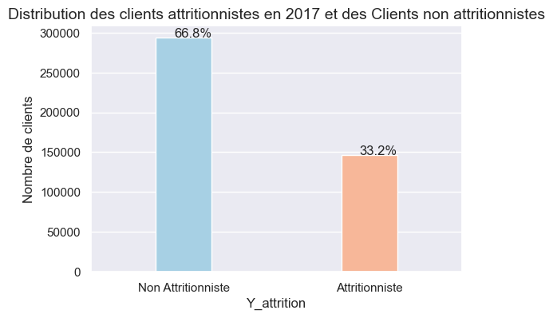

```python
# Distribution en pourcentage des clients Non Attritionniste et Attritionniste
# Nombre des clients attritionnistes et des Clients non attritionnistes

sns.set(style="darkgrid")
plt.figure(figsize=(6,4))
# plt.figure(figsize=(12,5))
total = float(len(dfTableAnalyse))

ax = sns.countplot(x='Y_attrition', data=dfTableAnalyse, palette='RdBu_r',saturation=0.99,width=0.3)

plt.ylabel ('Nombre de clients',size=12)
plt.title('Distribution des clients attritionnistes en 2017 et des Clients non attritionnistes', size=14)
for p in ax.patches:
    percentage = '{:.1f}%'.format(100 * p.get_height()/total)
    x = p.get_x() + p.get_width()
    y = p.get_height()
    ax.annotate(percentage, (x, y),ha='right',size=12)
plt.show()
```

## **4- Identification et Traitement**

### **4.1- Valeurs manquantes**

#### **4.1.1- Identification des valeurs manquantes**

```python
print(dfTableAnalyse.isnull().sum())
```

```
CIVILITE                0
TrancheAge              0
readhesion              0
DureeAdhesion           0
TrancheDureeAdhesion    0
Region_domiciliation    0
r_score                 0
f_score                 0
m_score                 0
Y_attrition             0
Region_achat            0
TIC_TOTALTTC_CAT        0
MONTANTREMISE_CAT       0
TOTAL_CAT               0
MARGESORTIE_CAT         0
U1_CAT                  0
U2_CAT                  0
U3_CAT                  0
U4_CAT                  0
dtype: int64
```

#### **4.1.2- Mesure du pourcentage des valeurs manquantes** :

- **Aucune valeurs manquantes dans le jeu de données**.

```python
# Affichage en pourcentage des valeurs manquantes
(dfTableAnalyse.isna().sum()/dfTableAnalyse.shape[0]).sort_values(ascending=True)
```

```
CIVILITE                0.0
U2_CAT                  0.0
U1_CAT                  0.0
MARGESORTIE_CAT         0.0
TOTAL_CAT               0.0
MONTANTREMISE_CAT       0.0
TIC_TOTALTTC_CAT        0.0
Region_achat            0.0
U3_CAT                  0.0
Y_attrition             0.0
f_score                 0.0
r_score                 0.0
Region_domiciliation    0.0
TrancheDureeAdhesion    0.0
DureeAdhesion           0.0
readhesion              0.0
TrancheAge              0.0
m_score                 0.0
U4_CAT                  0.0
dtype: float64
```

### **4.3- Doublons et valeurs abérantes**

- **L'identification éventuelle des doublons et des valeurs abérantes a été effectuée avant l'agrégation des différents fichiers**.

## **5- Analyse Univariée :**

- **Signification des variables** : Observation de la repartition des clients par modalité de la variable.
- Le rééquilibrage du jeu de données ne permet pas d'obtenir une bonne interprétation de la repartition des clients dans les variables. En effet, le jeu de données qui a été rééquilibré ne correspond plus au jeu de données réelle du commanditaire.

### **5.1- Variables Quantitatives**

**Observation de la repartition, de la distribution des clients pour chacune des variables continues.**

- DureeAdhesion
- r_score : C'est le score de la Récence (la date du dernier achat ou dernier contact du client).
- f_score : C'est le score de la fréquence (fréquence des achats sur une période de référence donnée).
- m_score : C'est le score du Montant (somme totale des achats cumulés sur cette période).

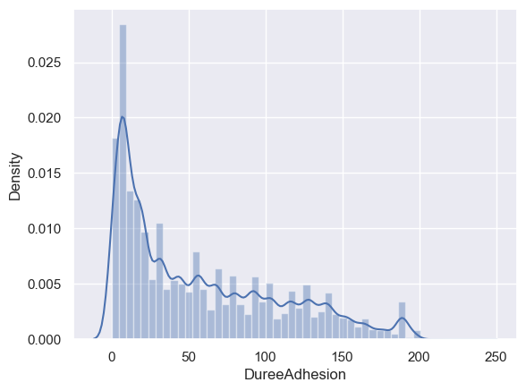

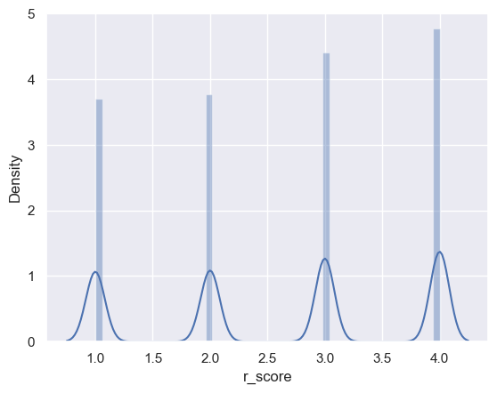

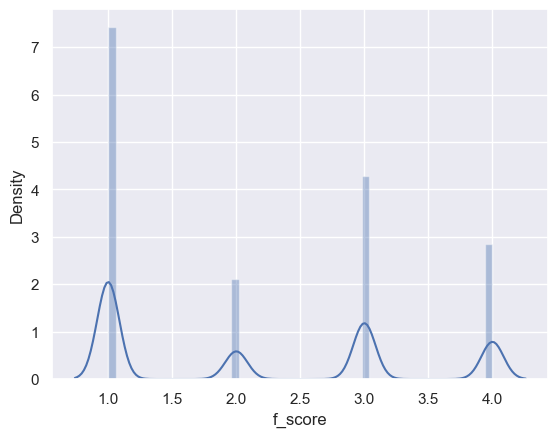

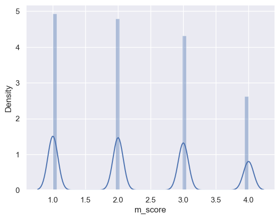

```python
# Observation de la repartition, de la distribution des données pour chacune des variables continues (colonnes)
for col in dfTableAnalyse.select_dtypes('int64'):
    plt.figure()
    sns.distplot(dfTableAnalyse[col])
```

**Note** :

### **5.2- Variables Qualitatives**

**Observation de la repartition, de la distribution des clients pour chacune des variables catégorielles.**

- CIVILITE
- TrancheAge
- readhesion
- TrancheDureeAdhesion
- Region_domiciliation
- Y_attrition
- Region_achat
- TIC_TOTALTTC_CAT
- MONTANTREMISE_CAT
- TOTAL_CAT
- MARGESORTIE_CAT
- U1_CAT
- U2_CAT
- U3_CAT
- U4_CAT

#### **CIVILITE** :

- Modalités : 2 (MADAME, MONSIEUR)

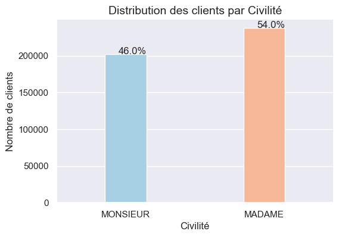

```python
# Distribution en pourcentage des clients par civilité

sns.set(style="darkgrid")
plt.figure(figsize=(6,4))
# plt.figure(figsize=(12,5))
total = float(len(dfTableAnalyse))

ax = sns.countplot(x='CIVILITE', data=dfTableAnalyse, palette='RdBu_r',saturation=0.99,width=0.3)

plt.xlabel ('Civilité',size=12)
plt.ylabel ('Nombre de clients',size=12)
plt.title('Distribution des clients par Civilité', size=14)
for p in ax.patches:
    percentage = '{:.1f}%'.format(100 * p.get_height()/total)
    x = p.get_x() + p.get_width()
    y = p.get_height()
    ax.annotate(percentage, (x, y),ha='right',size=12)
plt.show()
```

**Note** :

- Il y'a plus de clientes que de clients.

#### **TrancheAge** :

- Modalités : 4 (1_Sans age, 2_Moins de 40 ans, 3_Entre 40 et 60, 4_Plus de 60 ans)

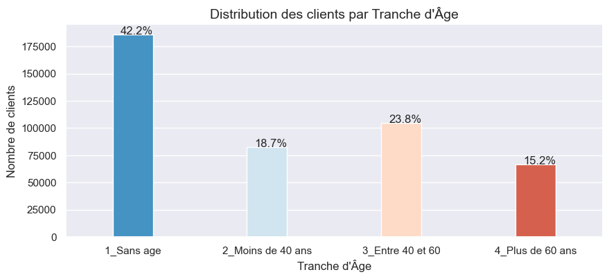

```python
# Distribution en pourcentage des clients par Tranche d'Âge

sns.set(style="darkgrid")
plt.figure(figsize=(10,4))
# plt.figure(figsize=(12,5))
total = float(len(dfTableAnalyse))

ax = sns.countplot(x='TrancheAge', data=dfTableAnalyse, palette='RdBu_r',saturation=0.99,width=0.3)

plt.xlabel ("Tranche d'Âge",size=12)
plt.ylabel ('Nombre de clients',size=12)
plt.title("Distribution des clients par Tranche d'Âge", size=14)
for p in ax.patches:
    percentage = '{:.1f}%'.format(100 * p.get_height()/total)
    x = p.get_x() + p.get_width()
    y = p.get_height()
    ax.annotate(percentage, (x, y),ha='right',size=12)
plt.show()
```

**Note** :

- Les clients les plus nombreux sont ceux qui n'ont pas renseignés leur âge.

#### **readhesion** :

- Modalités : 2 (non readherent, readherent )

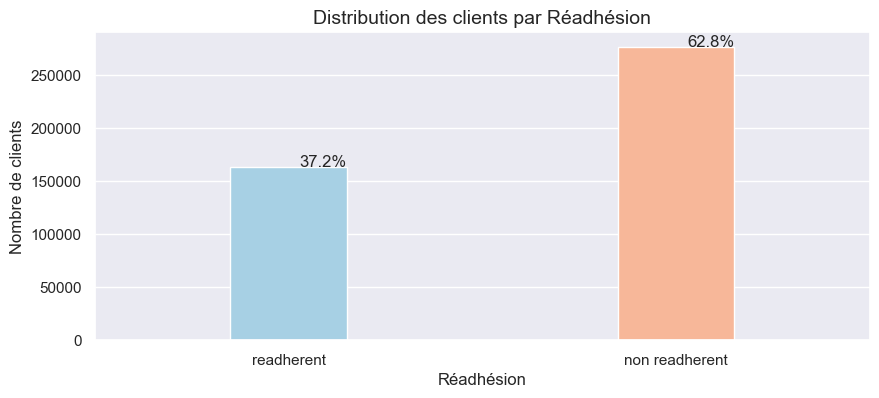

```python
# Distribution en pourcentage des clients par Réadhésion

sns.set(style="darkgrid")
plt.figure(figsize=(10,4))
# plt.figure(figsize=(12,5))
total = float(len(dfTableAnalyse))

ax = sns.countplot(x='readhesion', data=dfTableAnalyse, palette='RdBu_r',saturation=0.99,width=0.3)

plt.xlabel ("Réadhésion",size=12)
plt.ylabel ('Nombre de clients',size=12)
plt.title("Distribution des clients par Réadhésion", size=14)
for p in ax.patches:
    percentage = '{:.1f}%'.format(100 * p.get_height()/total)
    x = p.get_x() + p.get_width()
    y = p.get_height()
    ax.annotate(percentage, (x, y),ha='right',size=12)
plt.show()
```

**Note** :

- Il y a plus de clients qui ne réadhèrent pas.

#### **TrancheDureeAdhesion** :

- Modalités : 4 (1_Non adherent, 2_moins de 18 mois, 3_entre 18 et 46 mois, 4_suprieur à 46 mois)

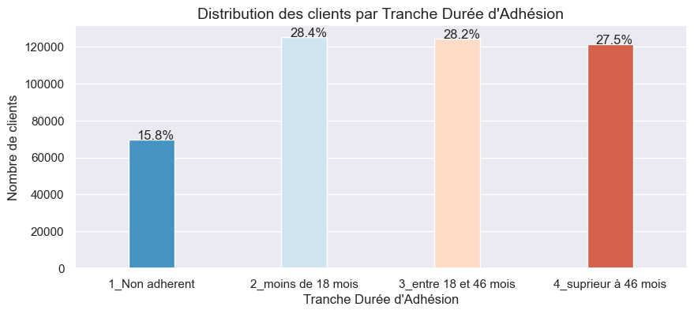

```python
# Distribution en pourcentage des clients par Tranche Durée d'Adhésion

sns.set(style="darkgrid")
plt.figure(figsize=(10,4))
# plt.figure(figsize=(12,5))
total = float(len(dfTableAnalyse))

ax = sns.countplot(x='TrancheDureeAdhesion', data=dfTableAnalyse, palette='RdBu_r',saturation=0.99,width=0.3)

plt.xlabel ("Tranche Durée d'Adhésion",size=12)
plt.ylabel ('Nombre de clients',size=12)
plt.title("Distribution des clients par Tranche Durée d'Adhésion", size=14)
for p in ax.patches:
    percentage = '{:.1f}%'.format(100 * p.get_height()/total)
    x = p.get_x() + p.get_width()
    y = p.get_height()
    ax.annotate(percentage, (x, y),ha='right',size=12)
plt.show()
```

**Note** :

- Les clients les plus nombreux sont ceux qui adhèrent pas plus de 18 mois.

#### **Region_domiciliation** :

- Modalités : 4 (Alsace-Est, Centre-Paris, Littoral, Rhône-Alpes,)

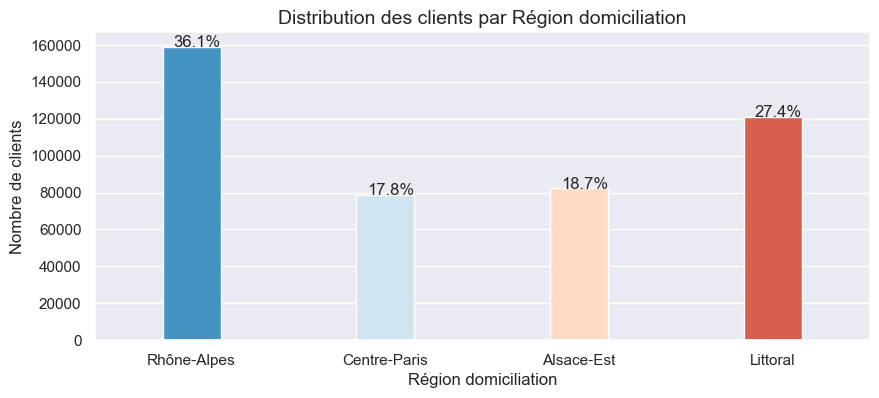

```python
# Distribution en pourcentage des clients par Region_domiciliation

sns.set(style="darkgrid")
plt.figure(figsize=(10,4))
# plt.figure(figsize=(12,5))
total = float(len(dfTableAnalyse))

ax = sns.countplot(x='Region_domiciliation', data=dfTableAnalyse, palette='RdBu_r',saturation=0.99,width=0.3)

plt.xlabel ("Région domiciliation",size=12)
plt.ylabel ('Nombre de clients',size=12)
plt.title("Distribution des clients par Région domiciliation", size=14)
for p in ax.patches:
    percentage = '{:.1f}%'.format(100 * p.get_height()/total)
    x = p.get_x() + p.get_width()
    y = p.get_height()
    ax.annotate(percentage, (x, y),ha='right',size=12)
plt.show()
```

**Note** :

- Les clients les plus nombreux sont ceux qui sont domiciliés dans la région Rhône-Alpes.

#### **r_score** :

- Modalités : 4 (1, 2, 3, 4)
- Une personne qui a déjà acheté récemment dans le magasin a plus de chances de revenir faire un nouvel achat.
  - 1 : clients qui appartiennent au groupe (groupe 1). Ce sont des clients qui ont effectués récemment des achats en 2016.
  - 2 : clients qui appartiennent au groupe (groupe 2). Ce sont des clients qui ont effectués des achats en 2016 plus récemment que les groupes 3 et 4
  - 3 : clients qui appartiennent au groupe (groupe 3). Ce sont des clients qui ont effectués des achats en 2016 plus récemment que le groupe 4
  - 4 : clients qui appartiennent au groupe (groupe 4). Ce sont des clients qui n'ont pas effectués récemment des achats en 2016.

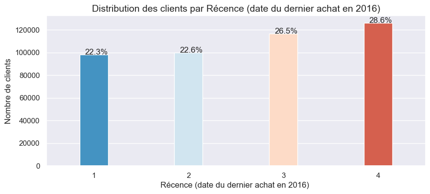

```python
# Distribution en pourcentage des clients par Récence (date du dernier achat)

sns.set(style="darkgrid")
plt.figure(figsize=(10,4))
# plt.figure(figsize=(12,5))
total = float(len(dfTableAnalyse))

ax = sns.countplot(x='r_score', data=dfTableAnalyse, palette='RdBu_r',saturation=0.99,width=0.3)

plt.xlabel ("Récence (date du dernier achat en 2016) ",size=12)
plt.ylabel ('Nombre de clients',size=12)
plt.title("Distribution des clients par Récence (date du dernier achat en 2016)", size=14)
for p in ax.patches:
    percentage = '{:.1f}%'.format(100 * p.get_height()/total)
    x = p.get_x() + p.get_width()
    y = p.get_height()
    ax.annotate(percentage, (x, y),ha='right',size=12)
plt.show()
```

**Note** :

- Les clients les plus nombreux sont ceux qui appartiennent au dernier groupe (groupe 4). Ce sont des clients qui n'ont pas effectués récemment des achats en 2016.

#### **f_score** :

- Modalités : 4 (1, 2, 3,4)
  - 1 : clients qui appartiennent au groupe (groupe 1). Ce sont qui achètent le moins fréquemment.
  - 2 : clients qui appartiennent au groupe (groupe 2). Ce sont ceux qui achètent plus fréquemment que ceux du groupe 1
  - 3 : clients qui appartiennent au groupe (groupe 3). Ce sont qui achètent plus fréquemment que ceux du groupe 2
  - 4 : clients qui appartiennent au groupe (groupe 4). Ce sont ceux qui achètent le plus fréquemment.

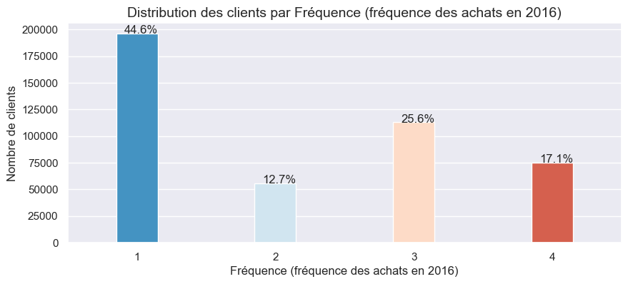

```python
# Distribution en pourcentage des clients par fréquence (fréquence des achats)

sns.set(style="darkgrid")
plt.figure(figsize=(10,4))
# plt.figure(figsize=(12,5))
total = float(len(dfTableAnalyse))

ax = sns.countplot(x='f_score', data=dfTableAnalyse, palette='RdBu_r',saturation=0.99,width=0.3)

plt.xlabel ("Fréquence (fréquence des achats en 2016)",size=12)
plt.ylabel ('Nombre de clients',size=12)
plt.title("Distribution des clients par Fréquence (fréquence des achats en 2016)", size=14)
for p in ax.patches:
    percentage = '{:.1f}%'.format(100 * p.get_height()/total)
    x = p.get_x() + p.get_width()
    y = p.get_height()
    ax.annotate(percentage, (x, y),ha='right',size=12)
plt.show()
```

**Note** :

- Les clients les plus nombreux sont ceux qui appartiennent au premier groupe. Ce sont ceux qui n'ont pas effectués régulièrement des achats en 2016.
- Plus le client achète régulièrement dans une enseigne, il y aura plus de probabilité qu’il achète à nouveau dans la même enseigne.
- Les clients de ce groupe (groupe 1) ne sont pas les clients fidèle.

#### **m_score** :

- Modalités : 4 (1, 2, 3, 4)
  - 1 : clients qui appartiennent au groupe (groupe 1). Ce sont ceux qui achètent le moins (petits acheteurs)
  - 2 : clients qui appartiennent au groupe (groupe 2). Ce sont ceux qui achètent plus que ceux du groupe 1
  - 3 : clients qui appartiennent au groupe (groupe 3). Ce sont ceux qui achètent plus que ceux du groupe 2
  - 4 : clients qui appartiennent au groupe (groupe 4). Ce sont ceux qui achètent le plus (grands acheteurs). Ce sont ceux qui ont le plus de valeurs.

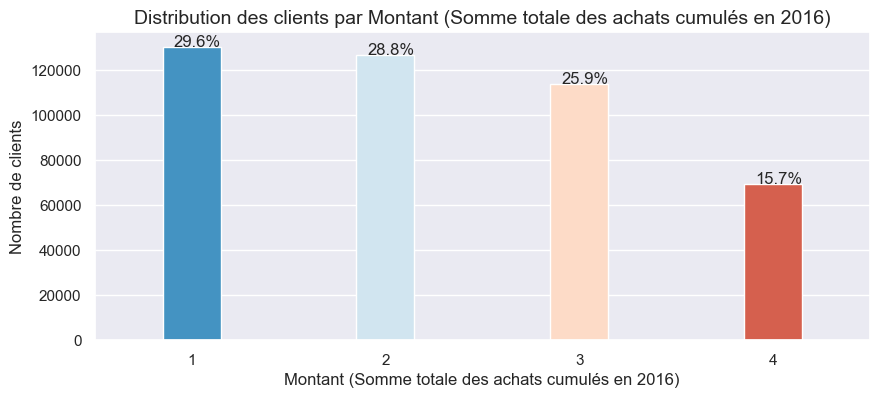

```python
# Distribution en pourcentage des clients par Montant (Somme totale des achats cumulés)

sns.set(style="darkgrid")
plt.figure(figsize=(10,4))
# plt.figure(figsize=(12,5))
total = float(len(dfTableAnalyse))

ax = sns.countplot(x='m_score', data=dfTableAnalyse, palette='RdBu_r',saturation=0.99,width=0.3)

plt.xlabel ("Montant (Somme totale des achats cumulés en 2016)",size=12)
plt.ylabel ('Nombre de clients',size=12)
plt.title("Distribution des clients par Montant (Somme totale des achats cumulés en 2016)", size=14)
for p in ax.patches:
    percentage = '{:.1f}%'.format(100 * p.get_height()/total)
    x = p.get_x() + p.get_width()
    y = p.get_height()
    ax.annotate(percentage, (x, y),ha='right',size=12)
plt.show()
```

**Note** :

- Les clients les plus nombreux sont ceux qui appartiennent au premier groupe.
- Ce sont les clients qui appartiennent au groupe (groupe 1) qui achète le moins.
- Ce sont ces clients qui peuvent répondre positivement aux opérations marketing et commerciales que les petits acheteurs. On mesure ici la valeur client.

#### **Region_achat** :

- Modalités : 4 (Alsace-Est, Centre-Paris, Littoral, Rhône-Alpes)

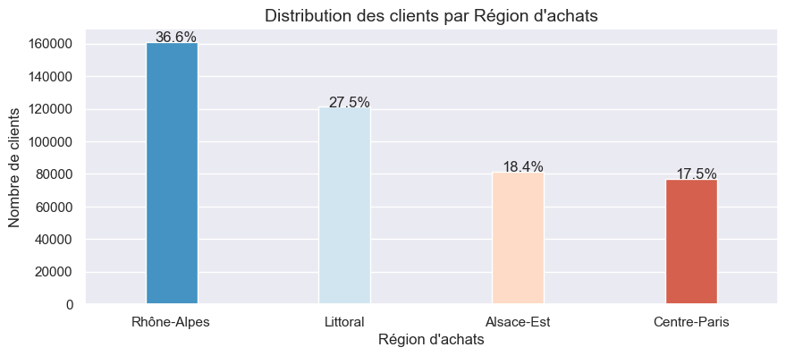

```python
# Distribution en pourcentage des clients par Region_achat

sns.set(style="darkgrid")
plt.figure(figsize=(10,4))
# plt.figure(figsize=(12,5))
total = float(len(dfTableAnalyse))

ax = sns.countplot(x='Region_achat', data=dfTableAnalyse, palette='RdBu_r',saturation=0.99,width=0.3)

plt.xlabel ("Région d'achats",size=12)
plt.ylabel ('Nombre de clients',size=12)
plt.title("Distribution des clients par Région d'achats", size=14)
for p in ax.patches:
    percentage = '{:.1f}%'.format(100 * p.get_height()/total)
    x = p.get_x() + p.get_width()
    y = p.get_height()
    ax.annotate(percentage, (x, y),ha='right',size=12)
plt.show()
```

**Note** :

- Les clients les plus nombreux sont ceux qui achètent dans la région Rhône-Alpes.

#### **TIC_TOTALTTC_CAT** :

TIC_TOTALTTC_CAT : Total (TTC) d'achats par ticket client

- Modalités : 4 (Q1_inferieur_59, Q2_entre_59_108, Q3_entre_108_184, Q4_superieur_184)

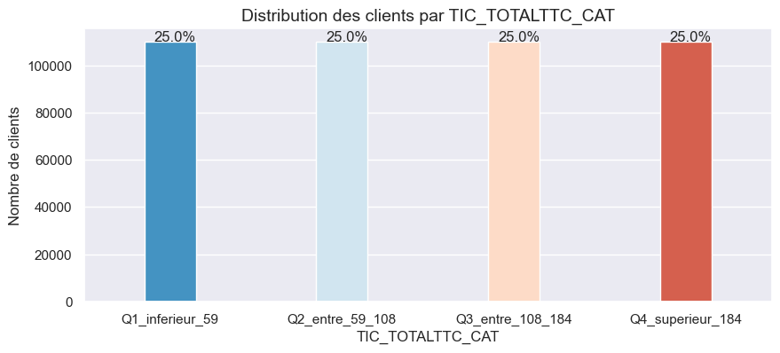

```python
# Distribution en pourcentage des clients par TIC_TOTALTTC_CAT

sns.set(style="darkgrid")
plt.figure(figsize=(10,4))
# plt.figure(figsize=(12,5))
total = float(len(dfTableAnalyse))

ax = sns.countplot(x='TIC_TOTALTTC_CAT', data=dfTableAnalyse, palette='RdBu_r',saturation=0.99,width=0.3)

plt.xlabel ("TIC_TOTALTTC_CAT",size=12)
plt.ylabel ('Nombre de clients',size=12)
plt.title("Distribution des clients par TIC_TOTALTTC_CAT", size=14)
for p in ax.patches:
    percentage = '{:.1f}%'.format(100 * p.get_height()/total)
    x = p.get_x() + p.get_width()
    y = p.get_height()
    ax.annotate(percentage, (x, y),ha='right',size=12)
plt.show()
```

**Note** :

#### **MONTANTREMISE_CAT** :

MONTANTREMISE_CAT : Montant de la remise par ticket

- Modalités : 4 (Q1_inferieur_0.5, Q2_entre_0.5_6, Q3_entre_6_12, Q4_superieur_12)

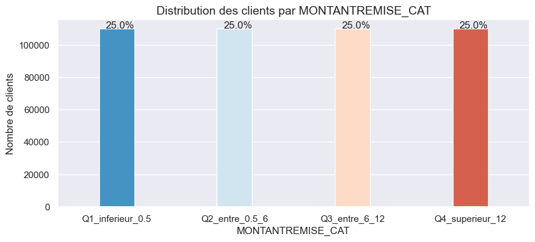

```python
# Distribution en pourcentage des clients par MONTANTREMISE_CAT

sns.set(style="darkgrid")
plt.figure(figsize=(10,4))
# plt.figure(figsize=(12,5))
total = float(len(dfTableAnalyse))

ax = sns.countplot(x='MONTANTREMISE_CAT', data=dfTableAnalyse, palette='RdBu_r',saturation=0.99,width=0.3)

plt.xlabel ("MONTANTREMISE_CAT",size=12)
plt.ylabel ('Nombre de clients',size=12)
plt.title("Distribution des clients par MONTANTREMISE_CAT", size=14)
for p in ax.patches:
    percentage = '{:.1f}%'.format(100 * p.get_height()/total)
    x = p.get_x() + p.get_width()
    y = p.get_height()
    ax.annotate(percentage, (x, y),ha='right',size=12)
plt.show()
```

**Note** :

#### **TOTAL_CAT** :

TOTAL_CAT : Total d'univers d'article par ticket d'achats.

- Modalités : 4 (Q1_inferieur_41, Q2_entre_41_77, Q3_entre_77_129, Q4_superieur_129)

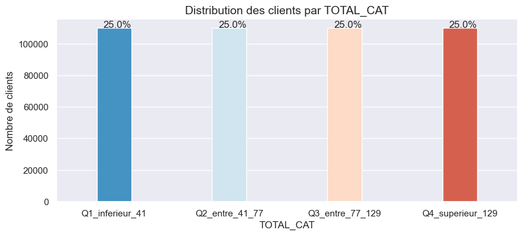

```python
# Distribution en pourcentage des clients par TOTAL_CAT

sns.set(style="darkgrid")
plt.figure(figsize=(10,4))
# plt.figure(figsize=(12,5))
total = float(len(dfTableAnalyse))

ax = sns.countplot(x='TOTAL_CAT', data=dfTableAnalyse, palette='RdBu_r',saturation=0.99,width=0.3)

plt.xlabel ("TOTAL_CAT",size=12)
plt.ylabel ('Nombre de clients',size=12)
plt.title("Distribution des clients par TOTAL_CAT", size=14)
for p in ax.patches:
    percentage = '{:.1f}%'.format(100 * p.get_height()/total)
    x = p.get_x() + p.get_width()
    y = p.get_height()
    ax.annotate(percentage, (x, y),ha='right',size=12)
plt.show()
```

**Note** :

#### **MARGESORTIE_CAT** :

- Modalités : 4 (Q1_inferieur_20, Q2_entre_20_37, Q3_entre_37_61, Q4_superieur_61)

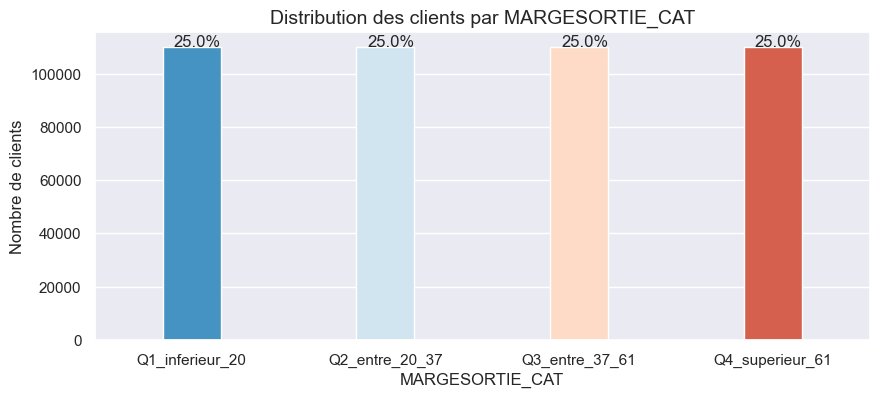

```python
# Distribution en pourcentage des clients par MARGESORTIE_CAT

sns.set(style="darkgrid")
plt.figure(figsize=(10,4))
# plt.figure(figsize=(12,5))
total = float(len(dfTableAnalyse))

ax = sns.countplot(x='MARGESORTIE_CAT', data=dfTableAnalyse, palette='RdBu_r',saturation=0.99,width=0.3)

plt.xlabel ("MARGESORTIE_CAT",size=12)
plt.ylabel ('Nombre de clients',size=12)
plt.title("Distribution des clients par MARGESORTIE_CAT", size=14)
for p in ax.patches:
    percentage = '{:.1f}%'.format(100 * p.get_height()/total)
    x = p.get_x() + p.get_width()
    y = p.get_height()
    ax.annotate(percentage, (x, y),ha='right',size=12)
plt.show()
```

**Note** :

#### **U1_CAT** :

U1_CAT : Nombre d'achats d'articles par client dans l'Univers 1

- Modalités : 4 (Q1_moins de 4, Q2_Entre 4 et 9, Q3_Entre 10 et 18, Q4_Superieur à 18)

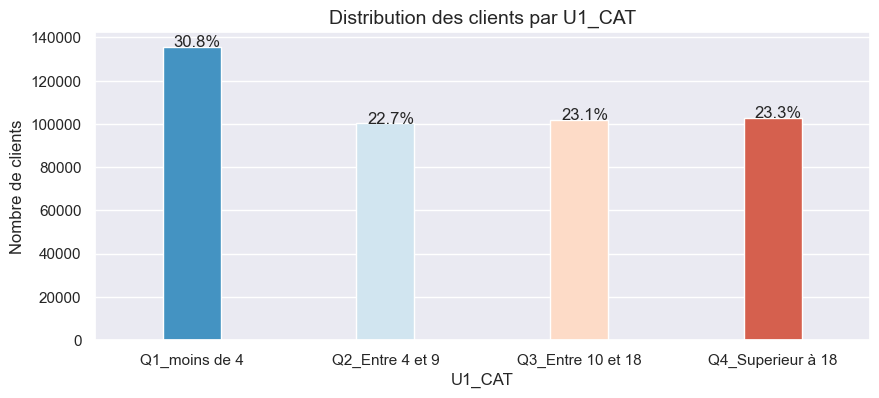

```python
# Distribution en pourcentage des clients par U1_CAT

sns.set(style="darkgrid")
plt.figure(figsize=(10,4))
# plt.figure(figsize=(12,5))
total = float(len(dfTableAnalyse))

ax = sns.countplot(x='U1_CAT', data=dfTableAnalyse, palette='RdBu_r',saturation=0.99,width=0.3)

plt.xlabel ("U1_CAT",size=12)
plt.ylabel ('Nombre de clients',size=12)
plt.title("Distribution des clients par U1_CAT", size=14)
for p in ax.patches:
    percentage = '{:.1f}%'.format(100 * p.get_height()/total)
    x = p.get_x() + p.get_width()
    y = p.get_height()
    ax.annotate(percentage, (x, y),ha='right',size=12)
plt.show()
```

**Note** :

- Les clients les plus nombreux sont ceux qui appartiennt au premier groupe : Q1_moins de 4.

#### **U2_CAT** :

U2_CAT : Nombre d'achats d'articles par client dans l'Univers 2

- Modalités : 4 (Q1_moins de 2, Q2_Entre 2 et 3, Q3_Entre 4 et 7, Q4_Superieur à 8)

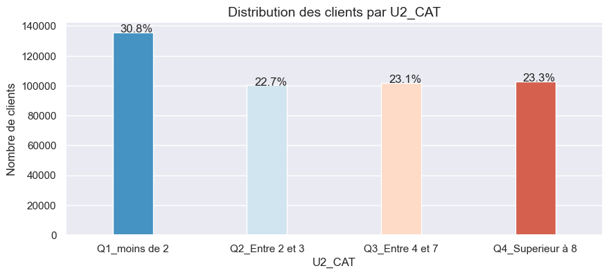

```python
# Distribution en pourcentage des clients par U2_CAT

sns.set(style="darkgrid")
plt.figure(figsize=(10,4))
# plt.figure(figsize=(12,5))
total = float(len(dfTableAnalyse))

ax = sns.countplot(x='U2_CAT', data=dfTableAnalyse, palette='RdBu_r',saturation=0.99,width=0.3)

plt.xlabel ("U2_CAT",size=12)
plt.ylabel ('Nombre de clients',size=12)
plt.title("Distribution des clients par U2_CAT", size=14)
for p in ax.patches:
    percentage = '{:.1f}%'.format(100 * p.get_height()/total)
    x = p.get_x() + p.get_width()
    y = p.get_height()
    ax.annotate(percentage, (x, y),ha='right',size=12)
plt.show()
```

**Note** :

- Les clients les plus nombreux sont ceux qui appartiennt au premier groupe : Q1_moins de 2.

#### **U3_CAT** :

U3_CAT : Nombre d'achats d'articles par client dans l'Univers 3

- Modalités : 2 (Q1_moins de 5, Q2_Superieur à 5)

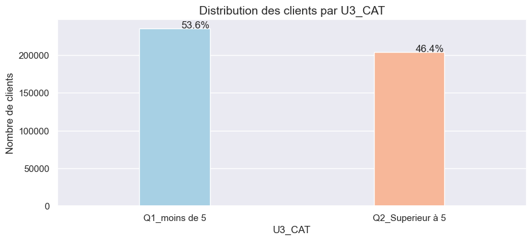

```python
# Distribution en pourcentage des clients par U3_CAT

sns.set(style="darkgrid")
plt.figure(figsize=(10,4))
# plt.figure(figsize=(12,5))
total = float(len(dfTableAnalyse))

ax = sns.countplot(x='U3_CAT', data=dfTableAnalyse, palette='RdBu_r',saturation=0.99,width=0.3)

plt.xlabel ("U3_CAT",size=12)
plt.ylabel ('Nombre de clients',size=12)
plt.title("Distribution des clients par U3_CAT", size=14)
for p in ax.patches:
    percentage = '{:.1f}%'.format(100 * p.get_height()/total)
    x = p.get_x() + p.get_width()
    y = p.get_height()
    ax.annotate(percentage, (x, y),ha='right',size=12)
plt.show()
```

**Note** :

- Les clients les plus nombreux sont ceux qui appartiennt au premier groupe : Q1_moins de 5.

#### **U4_CAT** :

U4_CAT : Nombre d'achats d'articles par client dans l'Univers 4

- Modalités : 2 (Q1_moins de 3, Q2_Superieur à 3)

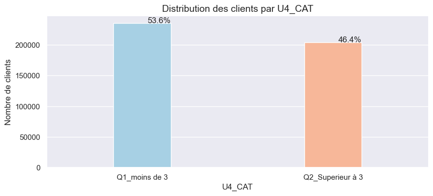

```python
# Distribution en pourcentage des clients par U4_CAT

sns.set(style="darkgrid")
plt.figure(figsize=(10,4))
# plt.figure(figsize=(12,5))
total = float(len(dfTableAnalyse))

ax = sns.countplot(x='U4_CAT', data=dfTableAnalyse, palette='RdBu_r',saturation=0.99,width=0.3)

plt.xlabel ("U4_CAT",size=12)
plt.ylabel ('Nombre de clients',size=12)
plt.title("Distribution des clients par U4_CAT", size=14)
for p in ax.patches:
    percentage = '{:.1f}%'.format(100 * p.get_height()/total)
    x = p.get_x() + p.get_width()
    y = p.get_height()
    ax.annotate(percentage, (x, y),ha='right',size=12)
plt.show()
```

**Note** :

- Les clients les plus nombreux sont ceux qui appartiennt au premier groupe : Q1_moins de 3.

## **6- Analyse Bivariée :**

- **Signification des variables** : Observation de la repartition des effectifs par modalité de la variable.
- Relation entre la **Variable cible (Target)** et les **Variables explicatives** ; Analyse plus détaillée (test du **Khi-deux** : Hypotheses nulle (H0))
- **Note** : Interprétation du résultat des graphiques : On compte le nombre d'apparition de chaque modalité de la variable sélectionnée pour les modalités "Attritionniste" et "Non Attritionniste" de la variable "Y_attrition"

**CE QUI SERA UTILISE POUR CETTE ANALYSE BIVARIEE** :

- **TABLEAU DE CONTINGENCE** : Le tableau de contingence nous permettra :
  - d’avoir une vue globale des modalité de chaque variables.
  - d’avoir une idée de la distribution conjointe des deux variables.
  - d’avoir une première idée sur la liaison des deux variables.
- **GRAPHIQUE** : Les graphiques (Diagramme en barre) vont nous permettre de transcrire de façon visuelle les idées véhiculées par le tableau de contingence.
- **Variable Target** : **Y_attrition**
  - **modalité cible** : Attritionniste (clients qui n'ont effectués aucun achat en 2017 et qui présentent un fort risque de départ)
  - **modalité non cible** : Non Attritionniste (clients qui ont effectués des achats en 2017 et qui ne présentent pas de risque de départ).
- **CHOIX DE LA MODALITE DE REFERENCE DES VARIABLES EXPLICATIVES** : La modalité de référence de chaque variables explicatives, est la modalité qui présente le pourcentage le plus élevé pour les clients non attritionnistes.
- **INDICATEURS STATISTIQUES** : Pour l'Evaluation des liaisons entre la variable cible et les variables explicatives. Cela nous sera utile pour la sélection des variables au cas nous avons plusieurs variables qualitatives dont nous voulons tester le lien avec la variable cible.
- **Le Test de "khi-deux"** :
- Pour mesurer la significativité de la variable explicative sur la variable cible.
- Pour tester l’indépendance entre les deux variables "qualitatives".
- **Fonctionnement du test khi-deux** : Le test **khi-deux** nous permet de choisir entre deux hypothèses : **H0**: les variables sont indépendantes Contre **H1**: les variables sont liées. Pour cela, sa statistique de test mesure l’écart entre le tableau de contingence observée et celui qu’on était censé observé si on avait une indépendance entre les variables.

Si le résultat du test nous fourni une p-value inférieur au seuil de **5%**, Alors, nous rejetons l’hypothèse nulle et donc les deux variables qualitatives sont liées.

### **6.1- Fonctions pour analyse bivariée**

- **Fonction TEST KHI-DEUX**
- **Fonction Graphique**

```python
# Fonction TEST KHI-DEUX
from scipy.stats import ttest_ind
from scipy.stats import chi2_contingency
def t_test(col,colY):
    alpha = 0.05
    tableau_contingence = pd.crosstab(dfTableAnalyse[col], dfTableAnalyse[colY])
    resultChi2 =chi2_contingency(tableau_contingence)
    stat = resultChi2[0]
    p = resultChi2[1]
    degree = resultChi2[2]
    print("Statistique de test observée :",stat )
    print("p-value du test :",p )
    #print('p-value du test : {}'.format(round(p,4)))

    print("dégré de liberté :",degree )
    if p < alpha:
        return "H0 Rejetée, la variable explicative " + col + " est susceptible d'être liée à la variable cible."
    else :
        return "H0 acceptée, la variable explicative " + col + " n'est pas liée à la variable cible."
        #return 0
```

```python
# Fonction Graphique
def GraphiqueBarrreStackAnalyse(df, VariableX, VariableY):
    cross_counts = pd.crosstab(df[VariableX], df[VariableY], normalize='index') * 100
    cross_counts.plot(kind='bar', stacked=True)
    for i in range(cross_counts.shape[0]):
        bottom = 0
        for j in range(cross_counts.shape[1]):
            value = cross_counts.iloc[i, j]
            plt.text(i, bottom + value / 2, f"{value:.2f}%", ha='center', va='center')
            bottom += value

    # Recherche du pourcentage le plus élevé et de son nom de série

    max_percentage = 0
    max_series = ""
    for j in range(cross_counts.shape[1]):
        value = cross_counts.iloc[i, j]
        if value > max_percentage:
            max_percentage = value
            #max_series = cross_counts.columns[j]
        bottom += value
    # Personnalisation du graphique
    plt.xlabel("La variable :" + VariableX)
    plt.ylabel('Pourcentage des clients')
    plt.legend(title="Attrition", loc='center left', bbox_to_anchor=(1, 0.5))
    plt.title("Analyse bivariée entre la variable cible Attrition et la variable explicative " + VariableX)

    # Affichage du graphique
    plt.show()
    #print(max_percentage)
    print("La modalité de référence pour la variable -- "+ VariableX + " -- est celle qui représente le pourcentage le plus élevé pour les clients non attritionnistes : " + str(max_series))
    print(f'{" " :-<100}')
    df_cross = df.sort_values(by=[VariableX])
    print(pd.crosstab(df[VariableX], df[VariableY],margins=True, normalize=True))
    print("/n")
    print(f'{VariableX :-<20} {t_test(VariableX, VariableY)}')
    print(f'{" " :-<100}')
```

### **6.2- Analyse bivariée - Graphique**

- **variable cible (Target)**
- **variable explicative**

#### **Target (Y_attrition) vs CIVILITE** :

- Modalités : 2 (MADAME, MONSIEUR)
- Modalité de référence : MADAME

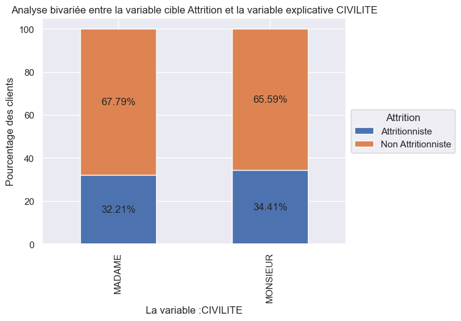

```
La modalité de référence pour la variable -- CIVILITE -- est celle qui représente le pourcentage le plus élevé pour les clients non attritionnistes :
 ---------------------------------------------------------------------------------------------------
Y_attrition  Attritionniste  Non Attritionniste      All
CIVILITE
MADAME             0.174018            0.366212  0.54023
MONSIEUR           0.158207            0.301563  0.45977
All                0.332225            0.667775  1.00000
/n
Statistique de test observée : 238.28045050981638
p-value du test : 9.325015737762354e-54
dégré de liberté : 1
CIVILITE------------ H0 Rejetée, la variable explicative CIVILITE est susceptible d'être liée à la variable cible.
 ---------------------------------------------------------------------------------------------------
```

```python
# Affichage du graphique
col="CIVILITE"
GraphiqueBarrreStackAnalyse(dfTableAnalyse, col, 'Y_attrition')
```

**Note** :

- Nous observons que les hommes sont un peu plus attritionnistes que les femmes.
- La variable **CIVILITE** est susceptible d'être liée à la variable **Attrition**.

#### **Target (Y_attrition) vs TrancheAge** :

- Modalités : 4 (1_Sans age, 2_Moins de 40 ans, 3_Entre 40 et 60, 4_Plus de 60 ans)
- Modalité de référence : 4_Plus de 60 ans

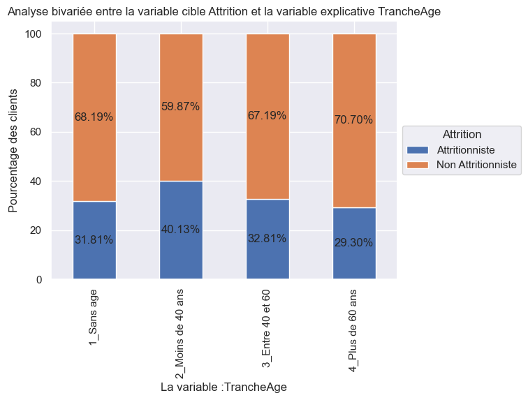

```
La modalité de référence pour la variable -- TrancheAge -- est celle qui représente le pourcentage le plus élevé pour les clients non attritionnistes :
 ---------------------------------------------------------------------------------------------------
Y_attrition        Attritionniste  Non Attritionniste       All
TrancheAge
1_Sans age               0.134340            0.288003  0.422343
2_Moins de 40 ans        0.075126            0.112102  0.187228
3_Entre 40 et 60         0.078220            0.160204  0.238424
4_Plus de 60 ans         0.044539            0.107465  0.152005
All                      0.332225            0.667775  1.000000
/n
Statistique de test observée : 2412.265657558403
p-value du test : 0.0
dégré de liberté : 3
TrancheAge---------- H0 Rejetée, la variable explicative TrancheAge est susceptible d'être liée à la variable cible.
 ---------------------------------------------------------------------------------------------------
```

```python
# Affichage du graphique
col="TrancheAge"
GraphiqueBarrreStackAnalyse(dfTableAnalyse, col, 'Y_attrition')
```

**Note** :

- Les clients qui ont Moins de 40 ans sont les plus attritionnistes.
- Les clients qui ont plus de 60 ans sont ceux qui sont les moins attritionnistes.
- La variable **TrancheAge** est susceptible d'être liée à la variable **Attrition**.

#### **Target (Y_attrition) vs readhesion** :

- Modalités : 2 (non readherent, readherent)
- Modalité de référence : non readherent

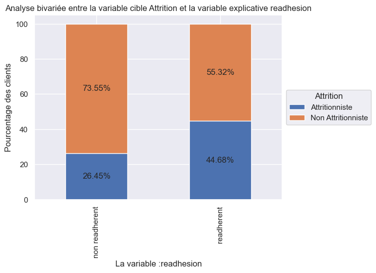

```
La modalité de référence pour la variable -- readhesion -- est celle qui représente le pourcentage le plus élevé pour les clients non attritionnistes :
 ---------------------------------------------------------------------------------------------------
Y_attrition     Attritionniste  Non Attritionniste       All
readhesion
non readherent        0.166177            0.462155  0.628333
readherent            0.166048            0.205620  0.371667
All                   0.332225            0.667775  1.000000
/n
Statistique de test observée : 15412.692055710435
p-value du test : 0.0
dégré de liberté : 1
readhesion---------- H0 Rejetée, la variable explicative readhesion est susceptible d'être liée à la variable cible.
 ---------------------------------------------------------------------------------------------------
```

```python
# Affichage du graphique
col="readhesion"
GraphiqueBarrreStackAnalyse(dfTableAnalyse, col, 'Y_attrition')
```

**Note** :

- Les clients qui réadhèrent sont les plus attritionnistes.
- La variable **readhesion** est susceptible d'être liée à la variable **Attrition**.

#### **Target - TrancheDureeAdhesion** :

- Modalités : 4 (1_Non adherent, 2_moins de 18 mois, 3_entre 18 et 46 mois, 4_suprieur à 46 mois)
- Modalité de référence : 4_suprieur à 46 mois

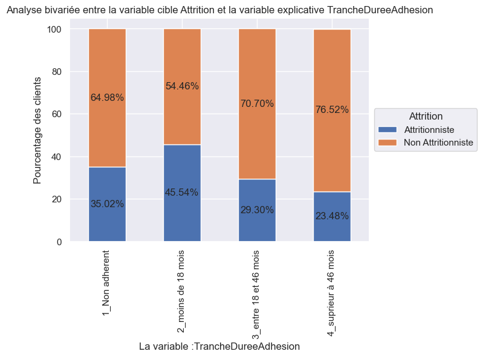

```
La modalité de référence pour la variable -- TrancheDureeAdhesion -- est celle qui représente le pourcentage le plus élevé pour les clients non attritionnistes :
 ---------------------------------------------------------------------------------------------------
Y_attrition            Attritionniste  Non Attritionniste       All
TrancheDureeAdhesion
1_Non adherent               0.055460            0.102895  0.158355
2_moins de 18 mois           0.129495            0.154832  0.284327
3_entre 18 et 46 mois        0.082670            0.199508  0.282178
4_suprieur à 46 mois         0.064601            0.210540  0.275140
All                          0.332225            0.667775  1.000000
/n
Statistique de test observée : 14727.4435077882
p-value du test : 0.0
dégré de liberté : 3
TrancheDureeAdhesion H0 Rejetée, la variable explicative TrancheDureeAdhesion est susceptible d'être liée à la variable cible.
 ---------------------------------------------------------------------------------------------------
```

```python
# Affichage du graphique
col="TrancheDureeAdhesion"
GraphiqueBarrreStackAnalyse(dfTableAnalyse, col, 'Y_attrition')
```

**Note** :

- Les clients qui ont une Durée d'Adhésion de moins de 18 mois sont les plus attritionnistes.
- La variable **TrancheDureeAdhesion** est susceptible d'être liée à la variable **Attrition**.

#### **Target - Region_domiciliation** :

- Modalités : 4 (Alsace-Est, Centre-Paris, Littoral, Rhône-Alpes,)
- Modalité de référence : Rhône-Alpes

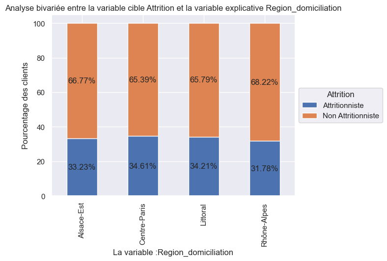

```
La modalité de référence pour la variable -- Region_domiciliation -- est celle qui représente le pourcentage le plus élevé pour les clients non attritionnistes :
 ---------------------------------------------------------------------------------------------------
Y_attrition           Attritionniste  Non Attritionniste       All
Region_domiciliation
Alsace-Est                  0.061982            0.124552  0.186534
Centre-Paris                0.061714            0.116579  0.178294
Littoral                    0.093874            0.180556  0.274430
Rhône-Alpes                 0.114655            0.246088  0.360742
All                         0.332225            0.667775  1.000000
/n
Statistique de test observée : 269.8338595912035
p-value du test : 3.352824290214262e-58
dégré de liberté : 3
Region_domiciliation H0 Rejetée, la variable explicative Region_domiciliation est susceptible d'être liée à la variable cible.
 ---------------------------------------------------------------------------------------------------
```

```python
# Affichage du graphique
col="Region_domiciliation"
GraphiqueBarrreStackAnalyse(dfTableAnalyse, col, 'Y_attrition')
```

**Note** :

- **Résultat du test de khi-deux** : H0 Rejetée, la variable explicative est susceptible d'être liée à la variable cible.
- **Interprétation du graphique** : Il n'y a pas de région en difficulté. Il n'y a pas plus d'attritionnistes dans une région que dans une autre.
- Cette variable ne jouera pas dans le modèle, car il n'y a pas de disparité (de différence dans les proportions).
- **Les 2 variables sont probablement en liaison.**

#### **Target - r_score** :

- Modalités : 4 (1, 2, 3, 4)
- Une personne qui a déjà acheté récemment dans le magasin a plus de chances de revenir faire un nouvel achat.
  - 1 : clients qui appartiennent au groupe (groupe 1). Ce sont des clients qui ont effectué récemment des achats en 2016.
  - 2 : clients qui appartiennent au groupe (groupe 2). Ce sont des clients qui ont effectué des achats en 2016 plus récemment que les groupes 3 et 4
  - 3 : clients qui appartiennent au groupe (groupe 3). Ce sont des clients qui ont effectué des achats en 2016 plus récemment que le groupe 4
  - 4 : clients qui appartiennent au groupe (groupe 4). Ce sont des clients qui n'ont pas effectué récemment des achats en 2016.
- Modalité de référence : 1

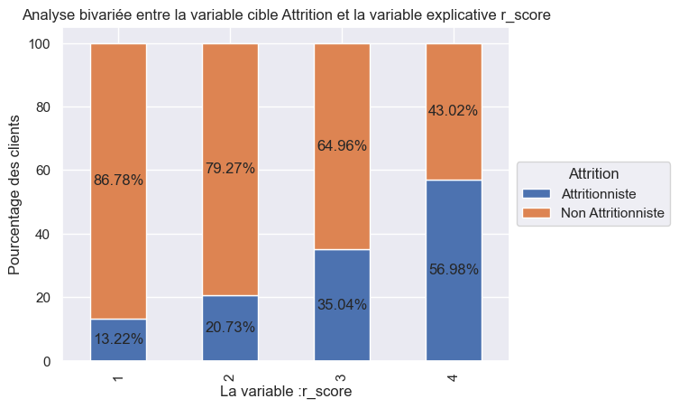

```
La modalité de référence pour la variable -- r_score -- est celle qui représente le pourcentage le plus élevé pour les clients non attritionnistes :
 ---------------------------------------------------------------------------------------------------
Y_attrition  Attritionniste  Non Attritionniste       All
r_score
1                  0.029423            0.193181  0.222604
2                  0.046963            0.179530  0.226493
3                  0.092687            0.171864  0.264551
4                  0.163152            0.123199  0.286351
All                0.332225            0.667775  1.000000
/n
Statistique de test observée : 56973.457592471386
p-value du test : 0.0
dégré de liberté : 3
r_score------------- H0 Rejetée, la variable explicative r_score est susceptible d'être liée à la variable cible.
 ---------------------------------------------------------------------------------------------------
```

```python
# Affichage du graphique
col="r_score"
GraphiqueBarrreStackAnalyse(dfTableAnalyse, col, 'Y_attrition')
```

**Note** :

- Les clients qui n'ont pas effectués récemment des achats en 2016 sont les plus attritionnistes.
- La variable **r_score** est susceptible d'être liée à la variable **Attrition**.

#### **Target - f_score** :

- Modalités : 4 (1, 2, 3,4)
  - 1 : clients qui appartiennent au groupe (groupe 1). Ce sont ceux qui achètent le moins fréquemment.
  - 2 : clients qui appartiennent au groupe (groupe 2). Ce sont ceux qui achètent plus fréquemment que ceux du groupe 1
  - 3 : clients qui appartiennent au groupe (groupe 3). Ce sont qui achètent plus fréquemment que ceux du groupe 2
  - 4 : clients qui appartiennent au groupe (groupe 4). Ce sont ceux qui achètent le plus fréquemment.
- Modalité de référence : 4

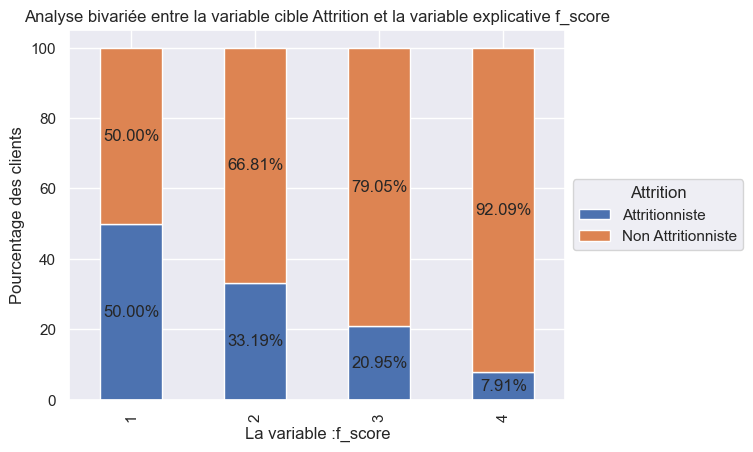

```
La modalité de référence pour la variable -- f_score -- est celle qui représente le pourcentage le plus élevé pour les clients non attritionnistes :
 ---------------------------------------------------------------------------------------------------
Y_attrition  Attritionniste  Non Attritionniste       All
f_score
1                  0.222808            0.222826  0.445634
2                  0.042179            0.084914  0.127094
3                  0.053719            0.202751  0.256470
4                  0.013519            0.157283  0.170802
All                0.332225            0.667775  1.000000
/n
Statistique de test observée : 54314.76082312598
p-value du test : 0.0
dégré de liberté : 3
f_score------------- H0 Rejetée, la variable explicative f_score est susceptible d'être liée à la variable cible.
 ---------------------------------------------------------------------------------------------------
```

```python
# Affichage du graphique
col="f_score"
GraphiqueBarrreStackAnalyse(dfTableAnalyse, col, 'Y_attrition')
```

**Note** :

- Ce sont les clients qui achètent le moins fréquemment qui sont les plus attritionnistes.
- La variable **f_score** est susceptible d'être liée à la variable **Attrition**.

#### **Target - m_score** :

- Modalités : 4 (1, 2, 3, 4)
- Modalité de référence : 4
- Modalités : 4 (1, 2, 3,4)
  - 1 : clients qui appartiennent au groupe (groupe 1). Ce sont ceux qui ont le montant le moins élevé.
  - 2 : clients qui appartiennent au groupe (groupe 2). Ce sont ceux qui ont le montant le moins élevé que ceux du groupe 3 et 4
  - 3 : clients qui appartiennent au groupe (groupe 3). Ce sont ceux qui ont le montant le moins élevé que ceux du groupe 4
  - 4 : clients qui appartiennent au groupe (groupe 4). Ce sont ceux qui ont le montant le plus élevé.
- Modalité de référence : 4

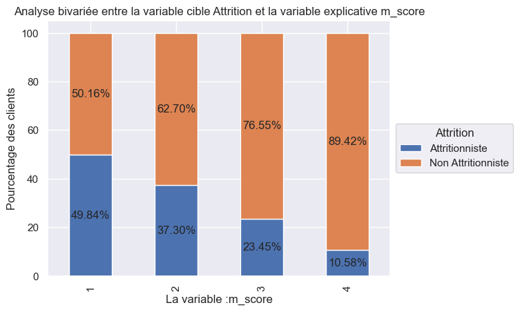

```
La modalité de référence pour la variable -- m_score -- est celle qui représente le pourcentage le plus élevé pour les clients non attritionnistes :
 ---------------------------------------------------------------------------------------------------
Y_attrition  Attritionniste  Non Attritionniste       All
m_score
1                  0.147525            0.148478  0.296003
2                  0.107332            0.180431  0.287763
3                  0.060732            0.198246  0.258978
4                  0.016637            0.140619  0.157256
All                0.332225            0.667775  1.000000
/n
Statistique de test observée : 38108.61155538442
p-value du test : 0.0
dégré de liberté : 3
m_score------------- H0 Rejetée, la variable explicative m_score est susceptible d'être liée à la variable cible.
 ---------------------------------------------------------------------------------------------------
```

```python
# Affichage du graphique
col="m_score"
GraphiqueBarrreStackAnalyse(dfTableAnalyse, col, 'Y_attrition')
```

**Note** :

- **Résultat du test de khi-deux** : H0 Rejetée, la variable explicative est susceptible d'être liée à la variable cible.
- **Interprétation du graphique** :

Ce sont les clients qui sont ceux qui ont le montant le moins élevé qui sont les plus attritionnistes.

- **Les 2 variables sont probablement en liaison.**

#### **Target - Region_achat** :

- Modalités : 4 (Alsace-Est, Centre-Paris, Littoral, Rhône-Alpes,)
- Modalité de référence : Rhône-Alpes

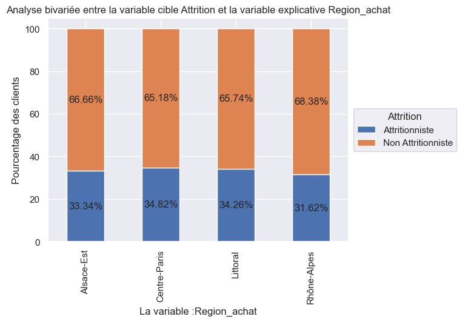

```
La modalité de référence pour la variable -- Region_achat -- est celle qui représente le pourcentage le plus élevé pour les clients non attritionnistes :
 ---------------------------------------------------------------------------------------------------
Y_attrition   Attritionniste  Non Attritionniste       All
Region_achat
Alsace-Est          0.061426            0.122804  0.184230
Centre-Paris        0.061018            0.114219  0.175237
Littoral            0.094223            0.180804  0.275027
Rhône-Alpes         0.115558            0.249948  0.365506
All                 0.332225            0.667775  1.000000
/n
Statistique de test observée : 335.49541561422063
p-value du test : 2.061428388782153e-72
dégré de liberté : 3
Region_achat-------- H0 Rejetée, la variable explicative Region_achat est susceptible d'être liée à la variable cible.
 ---------------------------------------------------------------------------------------------------
```

```python
# Affichage du graphique
col="Region_achat"
GraphiqueBarrreStackAnalyse(dfTableAnalyse, col, 'Y_attrition')
```

**Note** :

- **Analyse du diagnostic (Commentaire métier du graphique)** : Il n'y a pas de région en difficulté. Il n'y a pas plus d'attritionnistes dans une région que dans une autre.
- Cette variable ne jouera pas dans le modèle, car il n'y a pas de disparité (de différence dans les proportions).
- **Résultat du test de khi-deux** : H0 Rejetée, la variable explicative est susceptible d'être liée à la variable cible.
- **Les 2 variables sont probablement en liaison.**

#### **Target - TIC_TOTALTTC_CAT** :

- Modalités : 4 (Q1_inferieur_59, Q2_entre_59_108, Q3_entre_108_184, Q4_superieur_184)
- Modalité de référence : Q4_superieur_184

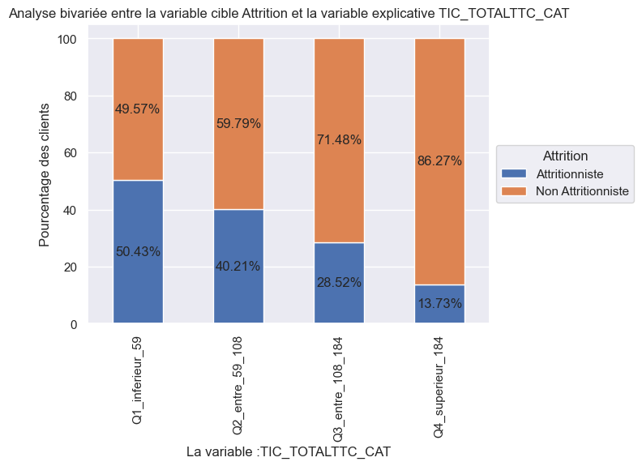

```
La modalité de référence pour la variable -- TIC_TOTALTTC_CAT -- est celle qui représente le pourcentage le plus élevé pour les clients non attritionnistes :
 ---------------------------------------------------------------------------------------------------
Y_attrition       Attritionniste  Non Attritionniste       All
TIC_TOTALTTC_CAT
Q1_inferieur_59         0.126075            0.123946  0.250020
Q2_entre_59_108         0.100537            0.149468  0.250005
Q3_entre_108_184        0.071284            0.178691  0.249975
Q4_superieur_184        0.034329            0.215671  0.250000
All                     0.332225            0.667775  1.000000
/n
Statistique de test observée : 37087.08120459775
p-value du test : 0.0
dégré de liberté : 3
TIC_TOTALTTC_CAT---- H0 Rejetée, la variable explicative TIC_TOTALTTC_CAT est susceptible d'être liée à la variable cible.
 ---------------------------------------------------------------------------------------------------
```

```python
# Affichage du graphique
col="TIC_TOTALTTC_CAT"
GraphiqueBarrreStackAnalyse(dfTableAnalyse, col, 'Y_attrition')
```

**Note** :

- **Résultat du test de khi-deux** : H0 Rejetée, la variable explicative est susceptible d'être liée à la variable cible.
- **Interprétation du graphique** : Ce sont les clients qui ont un total inférieur à 59 qui sont les plus attritionnistes.
- **Les 2 variables sont probablement en liaison.**